# Análisis de Datos Ómicos. Primera PEC

Alex Sánchez

2021-05-16

# Introducción

Esta PEC se basará en los datos de un estudio depositado en GEO con identificador “GSE46687” derivado de un estudio sobre identificación de genes que intervienen en la patogénesis del síndrome de Turner (ver Wang et al. 2020)

Utilizando los archivos .CEL descargados del sitio y una función ad-hoc que os proporcionaremos deberéis crear un subconjunto de muestras que será el que analizaréis.

Deberéis:

1. Plantear las cuestiones que deseáis responder
2. Realizar los análisis necesarios y
3. Elaborar un informe explicando problemas, métodos, resultados y discusión.

Recordad que *tan importante como el resultado es el razonamiento y el proceso que os leva a ello*, es decir el consultor debe poder ver no tan sólo donde habéis llegado sino también como y porque habéis llegado hasta allí.

# Obtención y lectura de los datos

## Los datos para el análisis

Los datos crudos pueden descargarse de GEO directamente accediendo a la dirección: https://www.ncbi.nlm.nih.gov/geo/query/acc.cgi?acc=GSE46687 donde encontramos el enlace para la descarga, al final de la página:

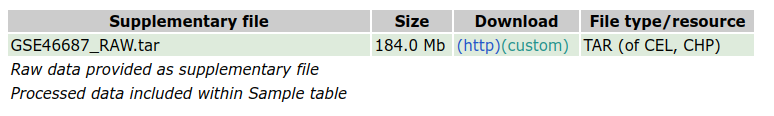

Descargamos los archivos comprimidos a un directorio “datos” que crearemos como subdirectorio de nuestro proyecto. Allí descomprimiremos dichos archivos hasta tener los archivos .CEL

## La “plataforma” o tipo de microarray

Para trabajar con microarrays, necesitamos conocer de que tgipo son, puesto que ello nos permite saber qué paquete de anotaciones necesitamos Esta información se encuentra también en la página de GEO correspondiente a los datos:

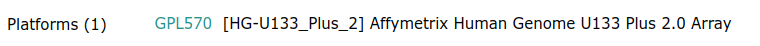

Esto nos indica que se trata de arrays de tipo 3’ITV en concreto el modelo HGU 133 plus 2 de Affymetrix, cuyas anotaciones se encuentran en el paquete `hgu133plus.db` de Bioconductor.

## Selección de muestras y carga de los datos

La lectura de datos se lleva a cabo utilizando las clases y métodos definidas en los paquetes `Biobase` y `oligo` de Bioconductor. Una forma cómoda de leer los datos y, al mismo tiempo, asignar a cada muestra los valores de las covariables (por ejemplo el grupo para el análisis) consiste en crear un pequeño archivo de texto, que suele denominarse `targets.csv` y que contiene la identificación de cada archivo con la asignación de cada muestra a cada condición experimental. En nuestro caso disponemos del archivo `targetsAll.csv` al que añadiremos los nombres de los archivos.

```r
listaArchivos <- list.files("datos")
nombres <- substr(listaArchivos, 1, 10)
targets0 <- read.csv("targetsAll.csv", row.names = 1)
if (sum(nombres == rownames(targets0))) targets <- cbind(filenames = listaArchivos,
    targets0)
```

El contenido del archivo `targets` se utiliza en la lectura de los datos y la creación del objeto `rawData` las intensidades “crudas” de cada archivo .CEL.

### Creación de un subconjunto para el análisis

Con el fin de que nuestro análisis contenga un número moderado de muestras podemos extraer aleatoriamente 6 muestras de cada grupo. Para ello utilizaremos la función `selectSample`para crear un nuevo objeto “targets” que tenga únicamente las filas seleccionadas.

```r
selectSamples <- function(myID) {
    set.seed(myID)
    selected <- c(sample(1:10, 6), 11, sample(12:26, 5), sample(27:36, 6))
    return(sort(selected))
}
```

Escogiendo como argumento el número “1234567” se obtiene:

```r
mySelected <- selectSamples(1234567)
selectedTargets <- targets[mySelected, ]
table(selectedTargets$karyotype)
```

```
45Xm 45Xp 46XX
   6    6    6
```

## Lectura de los datos

En primer lugar crearemos un objeto de tipo `annotatedDataFrame` que utilizaremos para leer los datos crudos.

```r
require(Biobase)
sampleInfo <- AnnotatedDataFrame(selectedTargets)
show(pData(sampleInfo))
```

```
                                          filenames    title karyotype
GSM1134016   GSM1134016_EA04058_25073_H133+_F15.CEL  XX_rep1      46XX
GSM1134017   GSM1134017_EA04058_25074_H133+_F16.CEL  XX_rep2      46XX
GSM1134018   GSM1134018_EA04058_25075_H133+_F20.CEL  XX_rep3      46XX
GSM1134020   GSM1134020_EA04058_25077_H133+_F34.CEL  XX_rep5      46XX
GSM1134022   GSM1134022_EA04058_25079_H133+_F42.CEL  XX_rep7      46XX
GSM1134025   GSM1134025_EA04058_25082_H133+_F52.CEL XX_rep10      46XX
GSM1134026 GSM1134026_EA04058_28124_H133+_TS208.CEL  Xm_rep1      45Xm
GSM1134027 GSM1134027_EA04058_28335_H133+_TS250.CEL  Xm_rep2      45Xm
GSM1134028 GSM1134028_EA04058_30434_H133+_TS258.CEL  Xm_rep3      45Xm
GSM1134032 GSM1134032_EA04058_52892_H133+_TS279.CEL  Xm_rep7      45Xm
GSM1134033 GSM1134033_EA04058_52893_H133+_TS236.CEL  Xm_rep8      45Xm
GSM1134041 GSM1134041_EA04058_53540_H133+_TS181.CEL Xm_rep16      45Xm
GSM1134042 GSM1134042_EA04058_30426_H133+_TS168.CEL  Xp_rep1      45Xp
GSM1134044  GSM1134044_EA04058_52884_H133+_TS11.CEL  Xp_rep3      45Xp
GSM1134045 GSM1134045_EA04058_52885_H133+_TS120.CEL  Xp_rep4      45Xp
GSM1134047 GSM1134047_EA04058_52887_H133+_TS234.CEL  Xp_rep6      45Xp
GSM1134048 GSM1134048_EA04058_52888_H133+_TS241.CEL  Xp_rep7      45Xp
GSM1134049 GSM1134049_EA04058_52890_H133+_TS266.CEL  Xp_rep8      45Xp
```

Dado que se trata de arrays algo antiguos, del tipo de los que aparecen en los materiales docentes podemos utilizar el paquete `affy` para leer los datos.

```r
library(affy)
fileNames <- paste0("datos/", pData(sampleInfo)$filenames)
rawData <- read.affybatch(filenames = fileNames, phenoData = sampleInfo)
show(rawData)
```

```
AffyBatch object
size of arrays=1164x1164 features (27 kb)
cdf=HG-U133_Plus_2 (54675 affyids)
number of samples=18
number of genes=54675
annotation=hgu133plus2
notes=
```

Este objeto es la base para todos los análisis que se realizarán.

# Preprocesado: Exploración, Control de Calidad y Normalización

Los datos procedentes de la lectura de los microarrays se denominan datos crudos y deben ser pre-procesados de diversas formas antes de analizarlos.

Pre- procesado es un término genérico que engloba varios procesos: - Exploración y control de calidad de los datos. - Normalización y resumen (llamdo sumarización) de los valores de las sondas de cada grupo de sondas. - Filtrado no especı́fico para eliminar el efecto de genes que no se expresano bien no se expresan de forma distinta entre los grupos.

A su vez la exploración y el control de calidad contempla: - Exploraciones estadı́sticas estándar. - Técnicas de control de calidad desarrolladas especı́ficamente para datos de microarrays.

## Exploración y visualización

La exploración de los datos suele basarse en técnicas univariantes como los histogramas o los diagramas de caja o en técnicas multivariantes como los análisis de conglomerados (clusters), de distancias o de análisis de componentes principales.

```r
## ----preajustes
colores <- c(rep("yellow", 6), rep("blue", 6), rep("red", 6))
formas <- c(rep(11, 6), rep(12, 6), rep(13, 6))
grupos <- as.factor(pData(rawData)$karyotype)
numSamples <- nrow(pData(rawData))
sampleNames <- pData(rawData)$title
colnames(exprs(rawData)) <- sampleNames
```

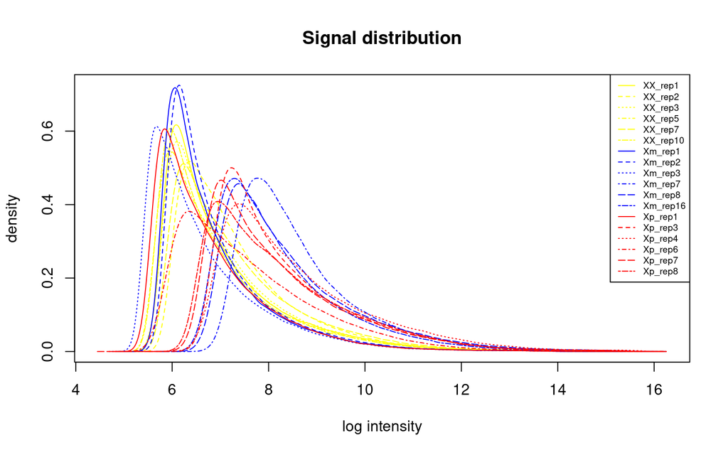

```r
## ----plotHist
hist(rawData, main = "Signal distribution", col = colores, lty = 1:numSamples)
legend(x = "topright", legend = sampleNames, col = colores, lty = 1:numSamples, cex = 0.6)
```

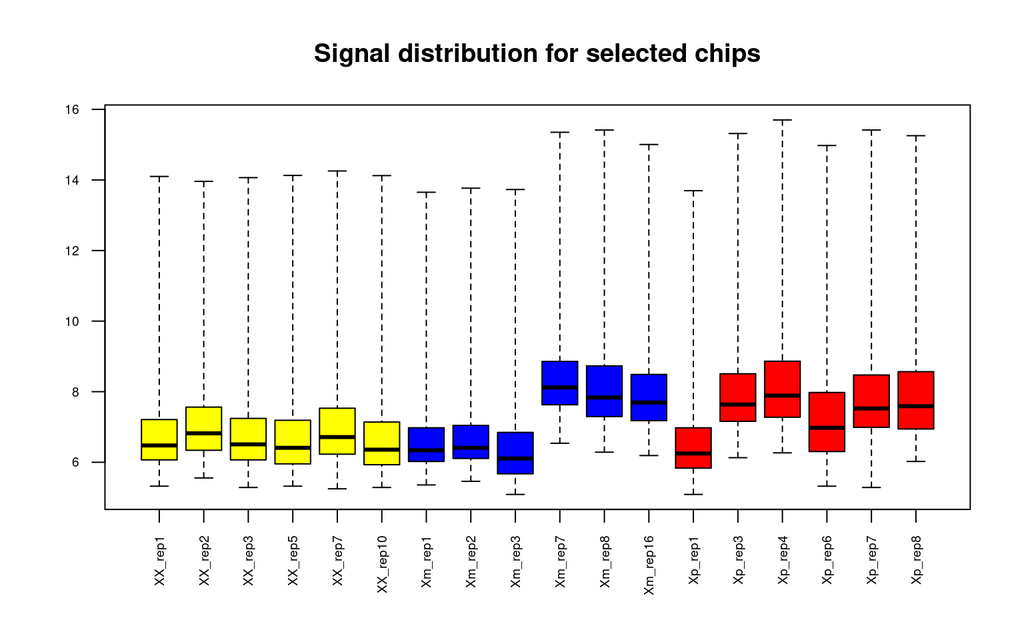

```r
## ----boxplot
boxplot(rawData, cex.axis = 0.6, col = colores, las = 2, names = sampleNames, main = "Signal distribution for selected chips")
```

El histograma y el diagram de caja muestran que las distribuciones de los datos son similares en formas pero no en posición, lo que ya sugiere que será preciso algun tipo de centrado.

```r
## ----plotPCA
library(ggplot2)
library(ggrepel)
plotPCA3 <- function(datos, labels, factor, title, scale, colores, size = 1.5, glineas = 0.25) {
    data <- prcomp(t(datos), scale = scale)
    # plot adjustments
    dataDf <- data.frame(data$x)
    Group <- factor
    loads <- round(data$sdev^2/sum(data$sdev^2) * 100, 1)
    # main plot
    p1 <- ggplot(dataDf, aes(x = PC1, y = PC2)) + theme_classic() + geom_hline(yintercept = 0,
        color = "gray70") + geom_vline(xintercept = 0, color = "gray70") + geom_point(aes(color = Group),
        alpha = 0.55, size = 3) + coord_cartesian(xlim = c(min(data$x[, 1]) - 5,
        max(data$x[, 1]) + 5)) + scale_fill_discrete(name = "Group")
    # avoiding labels superposition
    p1 + geom_text_repel(aes(y = PC2 + 0.25, label = labels), segment.size = 0.25,
        size = size) + labs(x = c(paste("PC1", loads[1], "%")), y = c(paste("PC2",
        loads[2], "%"))) + ggtitle(paste("Principal Component Analysis for: ", title,
        sep = " ")) + theme(plot.title = element_text(hjust = 0.5)) + scale_color_manual(values = colores)
}
```

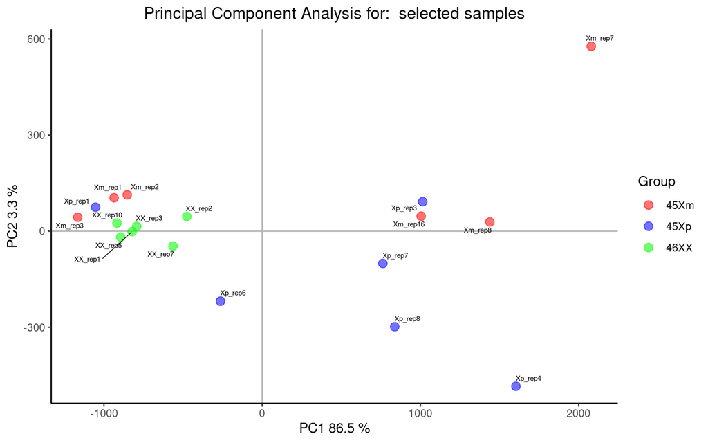

```r
## ----plotPCA2D
plotPCA3(exprs(rawData), labels = sampleNames, size = 2, factor = grupos, colores = c("red",
    "blue", "green"), title = "selected samples", scale = TRUE)
```

La representación de los datos en las dos primeras componentes principales muestra que no hay una separación clara entre los grupos lo que nos lleva a pensar que puede algún tipo de *efecto batch* que explique la diferencia.

Un cluster jerárquico refuerza esta impresión:

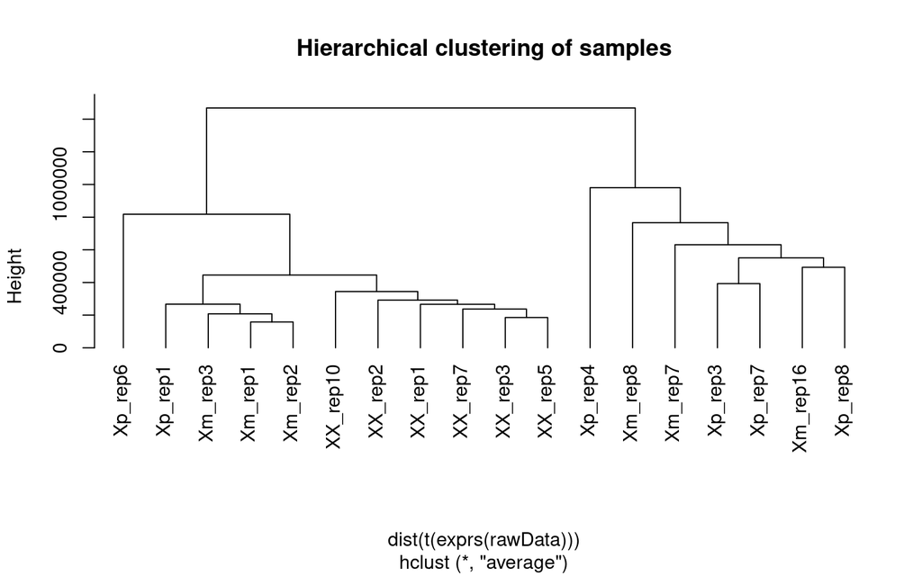

```r
clust.euclid.average <- hclust(dist(t(exprs(rawData))), method = "average")
plot(clust.euclid.average, labels = sampleNames, main = "Hierarchical clustering of samples",
    hang = -1)
```

La muestra `Xp_rep6` se separa de todas las demas. Una osibilidad es eliminarla del análisis.

El paquete `arrayQualitMetrics` encapsula todos los análisis anteriores, y alguno más, facilitando su ejecución e incluso su interpretación. La instrucción `arrayQualityMetrics` lleva a cabo todos los análisis de una vez y genera un informe de resultados con ayudas a la interpretación y a la detección de arrays problemáticos.

```r
library(arrayQualityMetrics)
arrayQualityMetrics(rawData, outdir = "arrayQuality", intgroup = "karyotype", force = TRUE)
```

Los resultados del control de calidad realizado con `arrayQualityMetrics` se encuentran accesibles a traves del archivo index.html contenido en el subdirectorio creado al invocarlo -en este caso denominado `arrayQuality`.

## Análisis de efectos batch (1)

Los análisis de componentes principales sugieren que puede haber algún factor que se superponga a las diferencias entre los grupos. Dado que no se dispone de información sobre otras covariables es difícil decidir si ésto es así. Una causa habitual del efectos batch es la fecha en que se procesan las muestras. Una búsqueda en Google muestra que es posible obtener la fecha de hibridación de los archivos .CEL mediante la funcion `get.celfile.dates` del paquete `affyio`.

```r
library(affyio)
HybDates <- as.factor(get.celfile.dates(fileNames))
show(HybDates)
```

```
 [1] 2005-10-25 2005-10-27 2005-10-25 2005-10-25 2005-10-25 2005-10-25
 [7] 2006-08-18 2006-08-18 2006-11-30 2008-08-05 2008-08-05 2008-08-05
[13] 2006-11-30 2008-08-05 2008-08-05 2008-08-05 2008-08-05 2008-08-05
Levels: 2005-10-25 2005-10-27 2006-08-18 2006-11-30 2008-08-05
```

```r
pData(rawData) <- cbind(pData(rawData), HybDates)
with(pData(rawData), table(HybDates, karyotype))
```

```
            karyotype
HybDates     45Xm 45Xp 46XX
  2005-10-25    0    0    5
  2005-10-27    0    0    1
  2006-08-18    2    0    0
  2006-11-30    1    1    0
  2008-08-05    3    5    0
```

La tabla muestra que la hibridación se ha hecho de la peor manera posible confundiendo fecha y cariotipo para el grupo 46XX. Esto significa que, **si se encuentran diferencias entre este grupo y los demás no podremos estar seguros de si atribuirlo a la diferencia en expresión o a un efecto técnico**. Es lamentable pero absolutamente habitual en estudios con espresión génica.

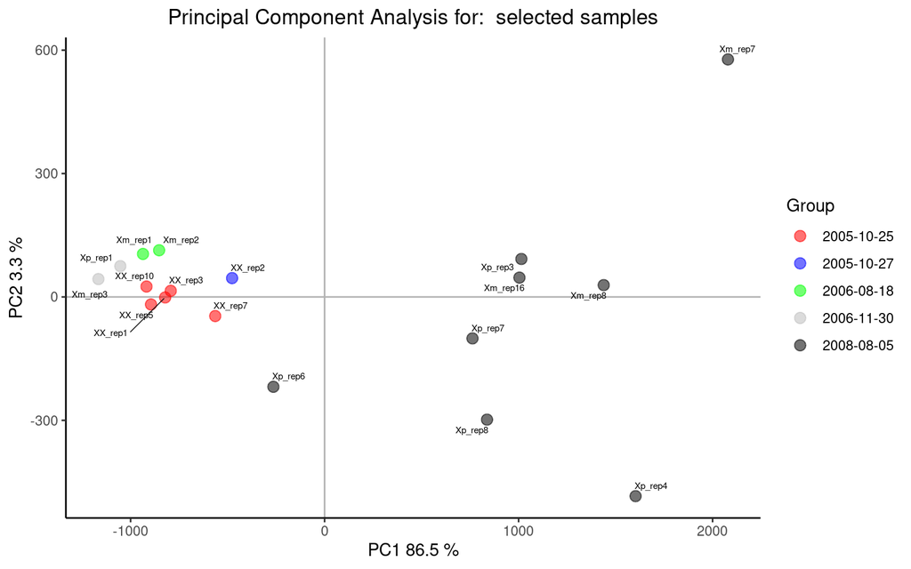

```r
plotPCA3(exprs(rawData), labels = sampleNames, size = 2, factor = HybDates, colores = c("red",
    "blue", "green", "grey", "black"), title = "selected samples", scale = TRUE)
```

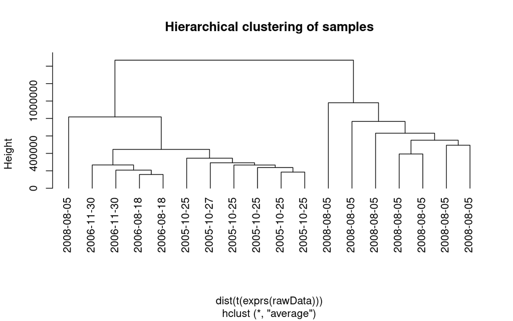

```r
plot(clust.euclid.average, labels = HybDates, main = "Hierarchical clustering of samples",
    hang = -1)
```

Dado que no todos los cariotipos estan presentes en todos los lotes no es posible eliminar el efecto batch completamente. Una forma de hacerlo, al menos en parte, es incluir la fecha como factor en el modelo de análisis.

## Normalizacion y Filtraje

Una vez realizado el control de calidad se procede a normalizar los datos y agregarlos.

La normalización puede hacerse por distintos métodos (MAS5, VSN, RMA, GCRMA, …) pero en este caso se utilizará el método RMA que es sin duda el más utilizado entre arrays de affymetrix.

El procesado mediante RMA implica un proceso en tres etapas: - Corrección de fondo (el RMA hace precisamente esto). - Normalización para hacer los valores de los arrays comparables. - Agregación (“Summarization”) de las diversas sondas asociadas a cada grupo de sondas para dar un único valor.

```r
library(affy)
eset_rma <- rma(rawData)
```

```
Background correcting
Normalizing
Calculating Expression
```

```r
eset_rma
```

```
ExpressionSet (storageMode: lockedEnvironment)
assayData: 54675 features, 18 samples
  element names: exprs
protocolData
  sampleNames: GSM1134016 GSM1134017 ... GSM1134049 (18 total)
  varLabels: ScanDate
  varMetadata: labelDescription
phenoData
  sampleNames: GSM1134016 GSM1134017 ... GSM1134049 (18 total)
  varLabels: filenames title karyotype HybDates
  varMetadata: labelDescription
featureData: none
experimentData: use 'experimentData(object)'
Annotation: hgu133plus2
```

## Filtraje

El filtraje no especı́fico permite eliminar los genes que varı́an poco entre condiciones o que deseamos quitar por otras razones como por ejemplo que no disponemos de anotación para ellos. La función `nsFilter` permite eliminar los genes que, o bien varı́an poco, o bien no se dispone de anotación para ellos. Si al filtrar deseamos usar las anotaciones, o la falta de ellas, como criterio de filtraje debemos disponer del correspondiente paquete de anotaciones.

Si al crear el objeto `expressionSet` no se le ha asignado una anotación debe hacerse antes de filtrar pera evitar un error, que se prodicirá en el caso que intentemos filtrar con el parametro `require.entrez`puesto en TRUE.

En este caso no hay problema porque el procedimiento de lectura identifica el tipo de array y rellena automáticamente el campo `annotation`.

```r
annotation(eset_rma)
```

```
[1] "hgu133plus2"
```

```r
library(genefilter)
filtered <- nsFilter(eset_rma, require.entrez = TRUE, remove.dupEntrez = TRUE, var.func = IQR,
    var.cutoff = 0.5, var.filter = TRUE, filterByQuantile = TRUE, feature.exclude = "^AFFX")

names(filtered)
```

```
[1] "eset"       "filter.log"
```

```r
class(filtered$eset)
```

```
[1] "ExpressionSet"
attr(,"package")
[1] "Biobase"
```

```r
print(filtered$filter.log)
```

```
$numDupsRemoved
[1] 21738

$numLowVar
[1] 10087

$numRemoved.ENTREZID
[1] 12753

$feature.exclude
[1] 10
```

```r
eset_filtered <- filtered$eset
```

El resultado del filtraje es un objeto `expressionSet` que, en lugar de 54675 “features” tiene 10087 que son los que estan anotados y tienen mayor variabilidad. La selección de genes se llevará a cabo sobre esta lista.

### Archivos de resultados normalizados

El resultado de la normalización y el filtraje es un objeto expressionSet almacenado en un archivo binario `datos.normalizados.Rda`, que será la base para todos los estudios posteriores.

```r
save(eset_rma, eset_filtered, file = paste0("results/", "datos.normalizados.Rda"))
```

# Selección de genes diferencialmente expresados

## Matrices de diseño y de contrastes

El primer paso para el análisis basado en modelos lineales es crear la matriz de diseño. Básicamente se trata de una tabla que describe la asignación de cada muestra a un grupo. Tiene tantas filas como muestras y tantas columnas como grupos (si solo se considera un factor)Cada fila contiene un uno en la columna del grupo al que pertenece la muestra y un cero en las restantes. La matriz de contrastes esse utiliza para describir las comparaciones entre grupos. Consta de tantas columnas como comparaciones y tantas filas como grupos (es decir como columnas de la matriz de diseño). Una comparación entre grupos –llamada “contraste”– se representa con un “1” y un “-1” en las filas de los grupos a comparar y ceros en las restantes. Si varios grupos intervinieran en la comparación se tendrı́a tantos coeeficientes como grupos con la única restricción de que su suma serı́a cero. La matriz de diseño puede definirse manualmente o a partir de un factor creado especı́ficamente para ello. Manualmente, seria:

```r
design1 <- matrix(c(1, 1, 1, 1, 1, 1, 0, 0, 0, 0, 0, 0, 0, 0, 0, 0, 0, 0, 0, 0, 0,
    0, 0, 0, 1, 1, 1, 1, 1, 1, 0, 0, 0, 0, 0, 0, 0, 0, 0, 0, 0, 0, 0, 0, 0, 0, 0,
    0, 1, 1, 1, 1, 1, 1), nrow = 18, byrow = F)
colnames(design1) <- c("XX", "Xm", "Xp")
rownames(design1) <- sampleNames
print(design1)
```

```
         XX Xm Xp
XX_rep1   1  0  0
XX_rep2   1  0  0
XX_rep3   1  0  0
XX_rep5   1  0  0
XX_rep7   1  0  0
XX_rep10  1  0  0
Xm_rep1   0  1  0
Xm_rep2   0  1  0
Xm_rep3   0  1  0
Xm_rep7   0  1  0
Xm_rep8   0  1  0
Xm_rep16  0  1  0
Xp_rep1   0  0  1
Xp_rep3   0  0  1
Xp_rep4   0  0  1
Xp_rep6   0  0  1
Xp_rep7   0  0  1
Xp_rep8   0  0  1
```

La instrucción model matrix permite generar la matriz de diseño a partir de uno o más factores:

```r
design1b <- model.matrix(~0 + grupos)
colnames(design1b) <- c("Xm", "Xp", "XX")
rownames(design1b) <- sampleNames
print(design1b)
```

```
         Xm Xp XX
XX_rep1   0  0  1
XX_rep2   0  0  1
XX_rep3   0  0  1
XX_rep5   0  0  1
XX_rep7   0  0  1
XX_rep10  0  0  1
Xm_rep1   1  0  0
Xm_rep2   1  0  0
Xm_rep3   1  0  0
Xm_rep7   1  0  0
Xm_rep8   1  0  0
Xm_rep16  1  0  0
Xp_rep1   0  1  0
Xp_rep3   0  1  0
Xp_rep4   0  1  0
Xp_rep6   0  1  0
Xp_rep7   0  1  0
Xp_rep8   0  1  0
attr(,"assign")
[1] 1 1 1
attr(,"contrasts")
attr(,"contrasts")$grupos
[1] "contr.treatment"
```

Las comparaciones que nos interesan son las diferencias, dos a dos entre cada cariotipo lo que puede hacerse con los contrastes siguientes:

```r
library(limma)
cont.matrix <- makeContrasts(XvsM = Xm - XX, XvsP = Xp - XX, MvsP = Xp - Xm, levels = design1)
print(cont.matrix)
```

```
      Contrasts
Levels XvsM XvsP MvsP
    XX   -1   -1    0
    Xm    1    0   -1
    Xp    0    1    1
```

## Estimación del modelo y selección de genes

Una vez definida la matriz de diseño y los contrastes podemos pasar a estimar el modelo, estimar los contrastes y realizar las pruebas de significación que nos indiquen, para cada gen y cada comparación, si puede considerarse diferencialmente expresado.

El método implementado en limma amplı́a el análisis tradicional utilizando modelos de Bayes empı́ricos para combinar la información de toda la matriz de datos y de cada gen individual y obtener estimaciones de error mejoradas.

El análisis proporciona los estadı́sticos de test habituales como Fold-change t-moderados o p-valores ajustados que se utilizan para ordenar los genes de más a menos diferencialmente expresados.

A fin de controlar el porcentaje de falsos positivos que puedan resultar del alto numero de contrastes realizados simultaneamente los p–valores se ajustan de forma que tengamos control sobre la tasa de falsos positivos utilizando el metodo de Benjamini y Hochberg.

```r
library(limma)
fit <- lmFit(eset_filtered, design1)
fit.main <- contrasts.fit(fit, cont.matrix)
fit.main <- eBayes(fit.main)
```

La funcion `topTable` genera para cada contraste una lista de genes ordenados de mas a menos diferencialmente expresados.

```r
topTab_XvsM <- topTable(fit.main, number = nrow(fit.main), coef = "XvsM", adjust = "fdr")
head(topTab_XvsM)
```

```
                logFC  AveExpr          t      P.Value    adj.P.Val         B
224588_at   -8.225348 8.017191 -13.349833 1.332621e-11 1.344215e-07 15.121571
219714_s_at -1.779475 7.994566  -8.192428 6.510978e-08 3.283812e-04  8.134443
219885_at   -1.159746 6.832092  -7.965078 1.017457e-07 3.421031e-04  7.739395
201058_s_at  3.546124 8.097213   7.711200 1.688679e-07 4.258427e-04  7.288500
231747_at   -1.219334 8.685359  -6.431343 2.476471e-06 3.823760e-03  4.859300
203990_s_at -1.418323 6.035336  -6.379686 2.772494e-06 3.823760e-03  4.755919
```

```r
topTab_XvsP <- topTable(fit.main, number = nrow(fit.main), coef = "XvsP", adjust = "fdr")
head(topTab_XvsP)
```

```
                logFC   AveExpr          t      P.Value    adj.P.Val         B
224588_at   -8.157018  8.017191 -13.238933 1.555408e-11 1.568940e-07 14.333945
201058_s_at  3.178442  8.097213   6.911659 8.811544e-07 4.444102e-03  5.661475
225617_at    1.095160  7.454150   6.633261 1.598014e-06 5.373057e-03  5.139713
203990_s_at -1.363069  6.035336  -6.131151 4.795500e-06 1.209305e-02  4.167638
212085_at   -1.001530 12.260836  -5.782370 1.047711e-05 1.848146e-02  3.470138
212736_at    0.921452  6.521241   5.761112 1.099324e-05 1.848146e-02  3.427071
```

```r
topTab_MvsP <- topTable(fit.main, number = nrow(fit.main), coef = "MvsP", adjust = "fdr")
head(topTab_MvsP)
```

```
                 logFC  AveExpr         t      P.Value adj.P.Val         B
225525_at   -1.1704222 6.558682 -4.711587 0.0001246589 0.6740924 -3.604958
219714_s_at  1.0083808 7.994566  4.642428 0.0001467189 0.6740924 -3.621318
204199_at    0.5791221 5.949438  4.346273 0.0002954466 0.6740924 -3.693982
210910_s_at -1.1758523 6.413491 -4.309178 0.0003225769 0.6740924 -3.703378
209255_at   -1.0358739 7.341516 -4.294311 0.0003341392 0.6740924 -3.707162
238345_at   -0.6148466 5.028936 -3.711715 0.0013265095 0.9998256 -3.863229
```

Un volcano-plot es una figuras que permite visualizar si hay muchos o pocos genes con un gran fold-change y significativamente expresados o si este número es bajo. Estos gráficos representa en abscisas los cambios de expresión en escala logarı́tmica y en ordenadas el “menos logaritmo” del p-valor o alternativamente el estadı́stico B (“log-odds”).

```r
library(annotate)
probeNames <- rownames(fit.main)
Symbols <- getSYMBOL(probeNames, annotation(eset_rma))
myNames <- paste(probeNames, Symbols, sep = ".")
head(myNames)
```

```
[1] "216705_s_at.ADA"     "242879_x_at.AKT3"    "207078_at.MED6"
[4] "207895_at.NAALADL1"  "236886_at.NINJ2-AS1" "236514_at.ACOT8"
```

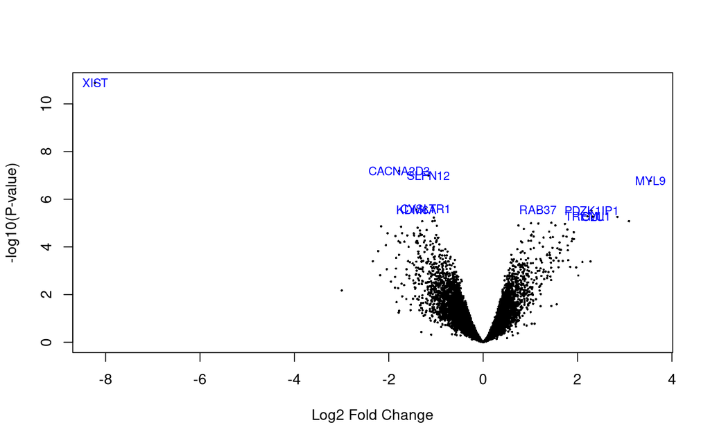

```r
volcanoplot(fit.main, coef = "XvsM", highlight = 10, names = Symbols)
```

## Comparaciones múltiples

Cuando se realizan varias comparaciones a la vez puede resultar importante ver que genes cambian simultáneamente en más de una comparación.

Si el número de comparaciones es alto también puede ser necesario realizar un ajuste de p-valores entre las comparaciones, distinto del realizado entre genes.

La función `decidetests` permite realizar ambas cosas. En este ejemplo no se ajustaran los p-valores entre comparaciones. Tan solo se seleccionaran los genes que cambian en una o más condiciones.

EL resultado del análisis es una tabla `res` que para cada gen y cada comparación contiene un 1 (si el gen esta sobre-expresado o `up'' en esta condicion), un 0 (si no hay cambio significativo) o un -1 (si esta`down’’-regulado).

```r
res <- decideTests(fit.main, method = "separate", adjust.method = "fdr", p.value = 0.05,
    lfc = 0)
```

Para resumir dicho análisis podemos contar qué filas tienen como mínimo una celda distinta de cero:

```r
sum.res.rows <- apply(abs(res), 1, sum)
res.selected <- res[sum.res.rows != 0, ]
print(summary(res))
```

```
        XvsM  XvsP  MvsP
Down     217    60     0
NotSig  9697  9963 10087
Up       173    64     0
```

Un diagrama de Venn permite visualizar la tabla anterior sin diferenciar entre genes `up'' o`down’’ regulados.

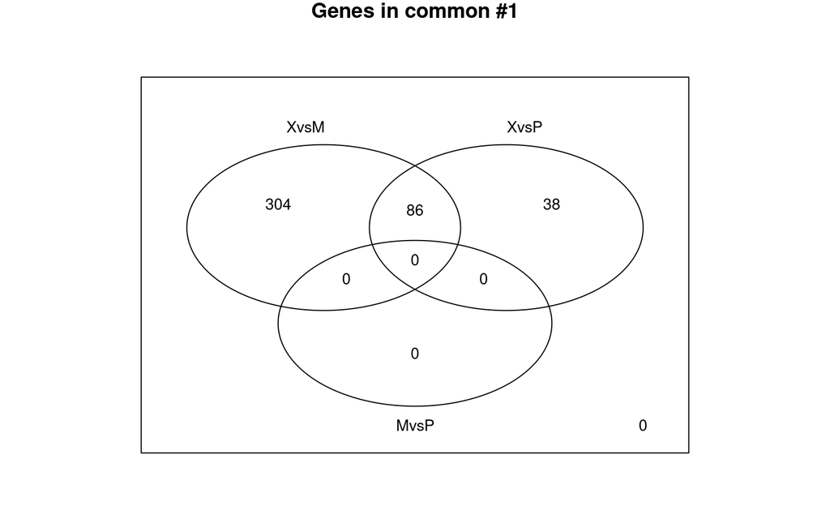

Número de genes seleccionado en cada comparacion

```r
vennDiagram(res.selected[, 1:3], main = "Genes in common #1", cex = 0.9)
```

## Resultados

El resultado es bastante claro y coincide con lo que habíamos visto en el análisis exploratorio:

- La diferencia más clara está entre los grupos XX y Xm
- XX y XP estan poco separados
- No se detectan diferencias entre XM y XP

Este resultado, sin embargo, tiene que quedar, en el mejor de los casos en entredicho puesto que, como se ha visto, las diferencias entre estos grupos coinciden con las que podríamos atribuir a los efectos batch.

Una alternativa que llevaríamos a cabo en una situación real sería repetir los análisis dentro de alguno de los lotes, por ejemplo las muestras hibridadas en 2008 y ver si coinciden con los anteriores, De ser así se confirmarían estos resultados pero la duda quedaría pendiente sobre las comparaciones en las que ésto no es posible.